# Paper Outline: The Global Sparsity and Regulatory Rigidity of Fecal Indicator Bacteria Monitoring

# Figure 1: Global Distribution and Ecosystem Footprint

### Executable R Code for Figure 1

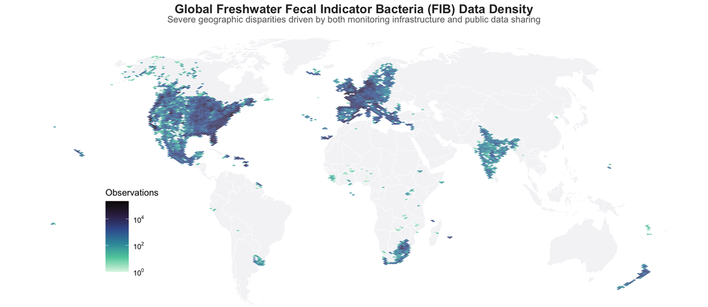

```r
# Load the cleaned dataset
clean_data <- read_feather("fecal_indicators_clean.feather", as_data_frame = FALSE)

# Pull coordinates for mapping
coords_data <- clean_data %>%
  select(lat, lon) %>%
  filter(!is.na(lat) & !is.na(lon)) %>%
  collect()

# Get world map outline in Robinson projection (excluding Antarctica)
world <- ne_countries(scale = "medium", returnclass = "sf") %>%
  filter(continent != "Antarctica")
world_robin <- st_transform(world, crs = "+proj=robin")

# Project coordinates to Robinson projection for hexbinning
coords <- as.matrix(coords_data[, c("lon", "lat")])
# Clean coords to ensure they are within bounds and exclude Antarctica (lat < -60)
valid_idx <- coords[, 1] >= -180 & coords[, 1] <= 180 & coords[, 2] >= -60 & coords[, 2] <= 90
coords_clean <- coords[valid_idx, ]
proj_coords <- sf_project(
  from = "+proj=longlat +datum=WGS84",
  to = "+proj=robin",
  pts = coords_clean
)
proj_df <- data.frame(x = proj_coords[, 1], y = proj_coords[, 2])

# Main map plot
p_map <- ggplot() +
  geom_sf(data = world_robin, fill = "#f5f5f7", color = "#ffffff", size = 0.2) +
  geom_hex(data = proj_df, aes(x = x, y = y), bins = 220, alpha = 0.85) +
  scale_fill_viridis_c(
    option = "mako",
    trans = "log10",
    direction = -1,
    name = "Observations",
    labels = scales::trans_format("log10", scales::math_format(10^.x))
  ) +
  coord_sf(ylim = c(-5950000, 8625155), expand = FALSE) +
  theme_void() +
  labs(
    title = "Global Freshwater Fecal Indicator Bacteria (FIB) Data Density",
    subtitle = "Severe geographic disparities driven by both monitoring infrastructure and public data sharing"
  ) +
  theme(
    plot.title = element_text(face = "bold", size = 15, hjust = 0.5, color = "#2d2d2d"),
    plot.subtitle = element_text(size = 11, hjust = 0.5, color = "#666666", margin = margin(b = 10)),
    legend.position = c(0.15, 0.28),
    legend.background = element_rect(fill = ggplot2::alpha("white", 0.7), color = NA),
    legend.key.width = unit(1.0, "cm")
  )

print(p_map)
```

# 2. Figure 2: Sampling Objectives & Mismatched Frequencies

### Executable R Code for Figure 2

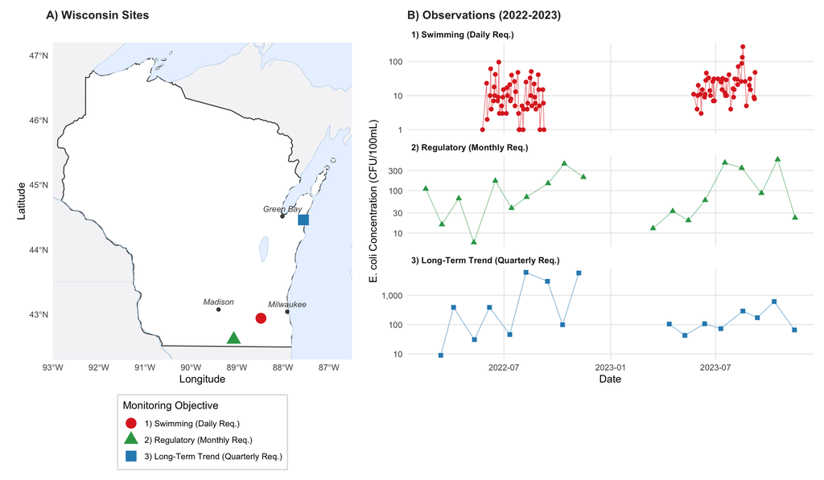

```r
# Load WI map boundaries
# Load map boundaries for USA states and filter Wisconsin to highlight it
states <- ne_states(country = "United States of America", returnclass = "sf")
wi_map <- states %>% filter(name == "Wisconsin")

# Download medium scale physical lakes and rivers
lakes_50m <- ne_download(scale = "medium", type = "lakes", category = "physical", returnclass = "sf")
rivers_50m <- ne_download(scale = "medium", type = "rivers_lake_centerlines", category = "physical", returnclass = "sf")

# Define major cities in Wisconsin for geographic reference
cities <- data.frame(
  name = c("Milwaukee", "Madison", "Green Bay"),
  lat = c(43.0389, 43.0731, 44.5133),
  lon = c(-87.9065, -89.4012, -88.0133)
)
cities_sf <- st_as_sf(cities, coords = c("lon", "lat"), crs = 4326)

# Define three representative freshwater sites in Wisconsin (Wisconsin DNR)
site_coords <- data.frame(
  site_id = c("WIDNR_WQX-683422", "WIDNR_WQX-543001", "WIDNR_WQX-313038"),
  label = c("1) Swimming (Daily Req.)", "2) Regulatory (Monthly Req.)", "3) Long-Term Trend (Quarterly Req.)"),
  lat = c(42.9374, 42.6091, 44.4585),
  lon = c(-88.4797, -89.0706, -87.5561)
)
site_coords_sf <- st_as_sf(site_coords, coords = c("lon", "lat"), crs = 4326)

# Plot zoomed-in Wisconsin map with surrounding states, hydrography, and major cities
p_ca_map <- ggplot() +
  geom_sf(data = states, fill = "#f5f5f7", color = "#e5e5ea", size = 0.2) +
  geom_sf(data = wi_map, fill = "#ffffff", color = "#4a4a4a", size = 0.5) +
  geom_sf(data = lakes_50m, fill = "#e8f2ff", color = "#a6c8e0", size = 0.15) +
  geom_sf(data = rivers_50m, color = "#a6c8e0", size = 0.3) +
  geom_sf(data = cities_sf, color = "#4a4a4a", size = 1.5) +
  geom_sf_text(data = cities_sf, aes(label = name), nudge_y = 0.12, size = 3, color = "#4a4a4a", fontface = "italic") +
  geom_sf(data = site_coords_sf, aes(color = label, shape = label), size = 5) +
  scale_color_manual(
    values = c(
      "1) Swimming (Daily Req.)" = "#de2d26",
      "2) Regulatory (Monthly Req.)" = "#31a354",
      "3) Long-Term Trend (Quarterly Req.)" = "#2b8cbe"
    ),
    name = "Monitoring Objective"
  ) +
  scale_shape_manual(
    values = c(
      "1) Swimming (Daily Req.)" = 16,
      "2) Regulatory (Monthly Req.)" = 17,
      "3) Long-Term Trend (Quarterly Req.)" = 15
    ),
    name = "Monitoring Objective"
  ) +
  coord_sf(xlim = c(-93.0, -86.5), ylim = c(42.3, 47.2), expand = FALSE) +
  theme_minimal() +
  theme(
    legend.position = "bottom",
    legend.direction = "vertical",
    legend.box.background = element_rect(color = "#d9d9d9", size = 0.5),
    panel.background = element_rect(fill = "#e8f2ff", color = NA), # Great Lakes / water fill
    plot.title = element_text(face = "bold", size = 12, color = "#2d2d2d")
  ) +
  labs(
    title = "A) Wisconsin Sites",
    x = "Longitude", y = "Latitude"
  )

# Extract observations for 2022-2023 for these three sites
ts_data <- clean_data %>%
  filter(site_id %in% c("WIDNR_WQX-683422", "WIDNR_WQX-543001", "WIDNR_WQX-313038")) %>%
  collect() %>%
  filter(date >= as.Date("2022-01-01") & date <= as.Date("2023-12-31")) %>%
  mutate(
    label = case_when(
      site_id == "WIDNR_WQX-683422" ~ "1) Swimming (Daily Req.)",
      site_id == "WIDNR_WQX-543001" ~ "2) Regulatory (Monthly Req.)",
      site_id == "WIDNR_WQX-313038" ~ "3) Long-Term Trend (Quarterly Req.)"
    )
  )

# Define helper function to insert NAs to break lines over winter/off-season gaps
insert_gaps <- function(df, max_gap) {
  if (nrow(df) < 2) return(df)
  df <- df[order(df$date), ]
  new_rows <- list()
  for (i in 1:(nrow(df) - 1)) {
    new_rows[[length(new_rows) + 1]] <- df[i, ]
    gap <- as.numeric(df$date[i+1] - df$date[i])
    if (gap > max_gap) {
      na_row <- df[i, ]
      na_row$date <- df$date[i] + 1
      na_row$val <- NA
      new_rows[[length(new_rows) + 1]] <- na_row
    }
  }
  new_rows[[length(new_rows) + 1]] <- df[nrow(df), ]
  do.call(rbind, new_rows)
}

# Apply insert_gaps with site-specific thresholds to avoid incorrect connecting lines
ts_data_with_na <- ts_data %>%
  group_by(label) %>%
  group_split() %>%
  lapply(function(df) {
    label_val <- df$label[1]
    max_gap <- case_when(
      label_val == "1) Swimming (Daily Req.)" ~ 15,
      label_val == "2) Regulatory (Monthly Req.)" ~ 45,
      label_val == "3) Long-Term Trend (Quarterly Req.)" ~ 120,
      TRUE ~ 30
    )
    insert_gaps(df, max_gap)
  }) %>%
  bind_rows()

# Generate stacked timeseries plot with broken lines for gaps
p_ts <- ggplot(ts_data_with_na, aes(x = date, y = val, color = label, shape = label)) +
  geom_line(size = 0.4, alpha = 0.5, na.rm = TRUE) +
  geom_point(size = 2, na.rm = TRUE) +
  scale_y_log10(labels = scales::comma) +
  scale_color_manual(
    values = c(
      "1) Swimming (Daily Req.)" = "#de2d26",
      "2) Regulatory (Monthly Req.)" = "#31a354",
      "3) Long-Term Trend (Quarterly Req.)" = "#2b8cbe"
    )
  ) +
  scale_shape_manual(
    values = c(
      "1) Swimming (Daily Req.)" = 16,
      "2) Regulatory (Monthly Req.)" = 17,
      "3) Long-Term Trend (Quarterly Req.)" = 15
    )
  ) +
  facet_wrap(~label, ncol = 1, scales = "free_y") +
  theme_minimal() +
  theme(
    legend.position = "none",
    strip.text = element_text(face = "bold", size = 9, hjust = 0),
    panel.grid.minor = element_blank(),
    plot.title = element_text(face = "bold", size = 12, color = "#2d2d2d")
  ) +
  labs(
    title = "B) Observations (2022-2023)",
    x = "Date",
    y = "E. coli Concentration (CFU/100mL)"
  )

# Combine map and timeseries side-by-side
p_fig2_combined <- p_ca_map + p_ts + plot_layout(widths = c(1, 1.3))
print(p_fig2_combined)
```

# 3. Figure 3: Quantifying the Actionability Gap

### Executable R Code for Figure 3

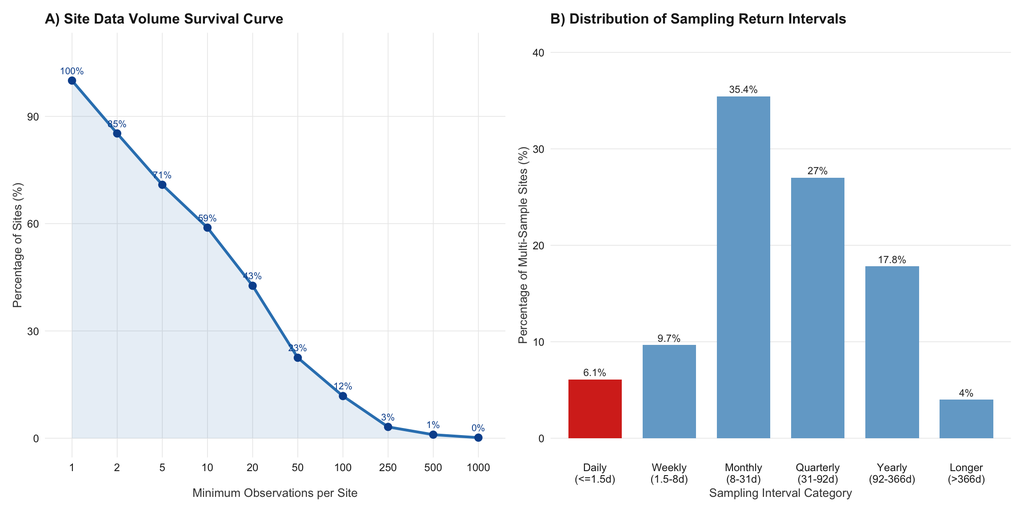

```r
# Group by site and calculate observation counts and spans
site_summary <- clean_data %>%
  select(site_id, lat, lon, date) %>%
  collect() %>%
  mutate(
    site_key = if_else(is.na(site_id), paste0("coord_", lat, "_", lon), site_id)
  ) %>%
  group_by(site_key) %>%
  summarise(
    n_obs = n(),
    min_date = min(date),
    max_date = max(date),
    span_days = as.numeric(max_date - min_date),
    .groups = "drop"
  )

# Part A: Threshold survival curve
thresholds <- c(1, 2, 5, 10, 20, 50, 100, 250, 500, 1000)
survival_df <- data.frame(
  threshold = thresholds,
  sites = sapply(thresholds, function(t) sum(site_summary$n_obs >= t))
) %>%
  mutate(pct = (sites / nrow(site_summary)) * 100)

p_survival <- ggplot(survival_df, aes(x = factor(threshold), y = pct, group = 1)) +
  geom_area(fill = "#3182bd", alpha = 0.12) +
  geom_line(color = "#3182bd", linewidth = 1.1) +
  geom_point(color = "#08519c", size = 2.6) +
  geom_text(aes(label = paste0(round(pct), "%")), vjust = -1, size = 2.8, color = "#08519c") +
  expand_limits(y = 108) +
  theme_pub(11) +
  labs(
    title = "A) Site Data Volume Survival Curve",
    x = "Minimum Observations per Site",
    y = "Percentage of Sites (%)"
  )

# Part B: Sampling interval distribution
interval_df <- site_summary %>%
  filter(n_obs >= 2) %>%
  mutate(
    avg_interval = span_days / (n_obs - 1)
  ) %>%
  mutate(
    interval_cat = case_when(
      avg_interval <= 1.5 ~ "Daily\n(<=1.5d)",
      avg_interval > 1.5 & avg_interval <= 8 ~ "Weekly\n(1.5-8d)",
      avg_interval > 8 & avg_interval <= 31 ~ "Monthly\n(8-31d)",
      avg_interval > 31 & avg_interval <= 92 ~ "Quarterly\n(31-92d)",
      avg_interval > 92 & avg_interval <= 366 ~ "Yearly\n(92-366d)",
      avg_interval > 366 ~ "Longer\n(>366d)",
      TRUE ~ "Unknown"
    )
  ) %>%
  count(interval_cat) %>%
  mutate(pct = (n / sum(n)) * 100)

# Reorder categories logically
interval_df$interval_cat <- factor(
  interval_df$interval_cat,
  levels = c("Daily\n(<=1.5d)", "Weekly\n(1.5-8d)", "Monthly\n(8-31d)", "Quarterly\n(31-92d)", "Yearly\n(92-366d)", "Longer\n(>366d)")
)

# Highlight the policy-relevant "Daily" category (the key finding: very few sites)
interval_df$highlight <- ifelse(grepl("Daily", interval_df$interval_cat), "Daily", "Other")

p_intervals <- ggplot(interval_df, aes(x = interval_cat, y = pct, fill = highlight)) +
  geom_col(show.legend = FALSE, width = 0.72) +
  geom_text(aes(label = paste0(round(pct, 1), "%")), vjust = -0.5, size = 3, color = "#2d2d2d") +
  scale_fill_manual(values = c("Daily" = "#d7301f", "Other" = "#74a9cf")) +
  expand_limits(y = max(interval_df$pct) * 1.13) +
  theme_pub(11) +
  theme(panel.grid.major.x = element_blank()) +
  labs(
    title = "B) Distribution of Sampling Return Intervals",
    x = "Sampling Interval Category",
    y = "Percentage of Multi-Sample Sites (%)"
  )

# Combine plots side-by-side
p_fig3_combined <- p_survival + p_intervals
print(p_fig3_combined)
```

# Figure 4: Reclaiming Recreation Days through High-Frequency Monitoring

### Conceptual Description

- **Aims:** Demonstrate that bacterial pollution in recreational waters is transient and that high-frequency data from across the globe allows precise management.
- **Visual Components:**
  - **Panel A (Map):** A global map in Robinson projection showing the location of three high-frequency case studies: Euclid Beach (USA), River Lune (UK), and Taruheru River (New Zealand).
  - **Panel B (Timeseries):** A 3-column timeseries layout showing the high-frequency variation of E. coli in 2023 for all three sites relative to the safety limit of 235 CFU/100mL, highlighting short-lived spikes and rapid recovery.
- **Key Findings & Concept:**
  - Pollution is a passing state, not a permanent attribute of most beaches or rivers.
  - With monthly sampling, a single bad sample can impair a beach for an entire month. High-frequency daily sampling allows managers to target closures precisely (only closing during short-lived spikes) and keep the waters open for recreation on the remaining safe days (see [populationmedicine.eu’s paper on daily vs weekly sampling and predictive models](https://doi.org/10.18332/popmed/163820)).